# Final Project - OSU Building Data Analysis

Jack Woods

3/13/2020

# Introduction

In 2007, Oregon State University (OSU) President Ed Ray signed the American College and University Presidents Climate Commitment, pledging institution-wide carbon neutrality by 2025. Normalized for growth, OSU has since reduced carbon emissions by 41% per student per square foot of building space; however, greenhouse gas emissions have only declined by 12% overall. OSU’s current annual carbon footprint is equivalent to over 15,000 average American homes, totalling over 134,000 metric tons of $CO_2e$ ($CO_2$ equivalent emissions). Although significant progress has been made, carbon neutrality will not be achieved by 2025 unless additional emissions reductions can be achieved.

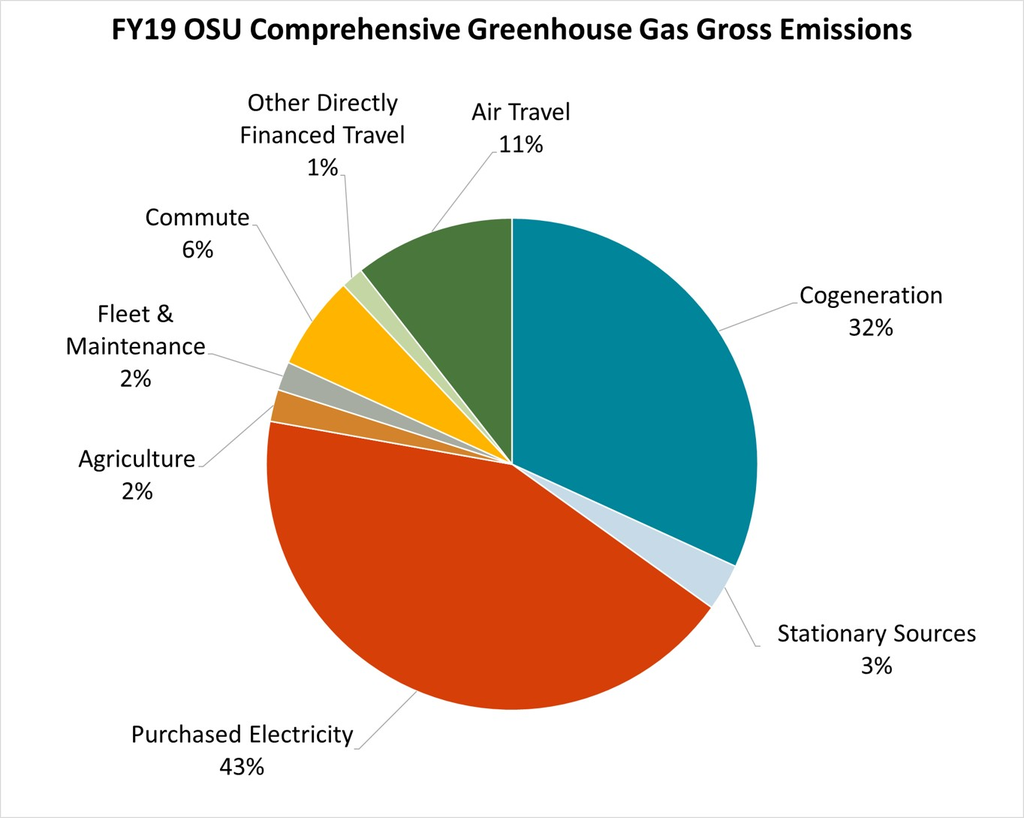

Emissions Pie Chart

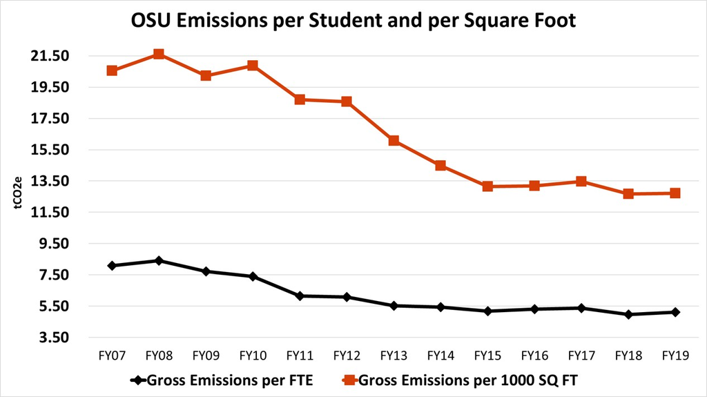

Emissions Per Student

The OSU Sustainability Office reports that electricity consumption accounts for approximately 75% of OSU’s carbon emissions. Thus, understanding electricity consumption patterns is a critical step towards advancing OSU’s emissions reduction initiatives. As Climate Change contributes to increasingly unstable climate/weather/temperatures worldwide, understanding the connection between OSU’s electricity consumption and Corvallis’s weather is critical for determining:

- The effects of Climate Change on OSU’s electricity consumption patterns.
- Whether Global Warming/Climate Change will cause campus-wide energy consumption to decrease or increase.
- Other patterns in daily, weekly, monthly, quarterly, or seasonal consumption.

This project aims to connect weather conditions to energy consumption in buildings across OSU’s Corvallis Campus by comparing energy, building, and weather data from June 1, 2018 to March 7, 2020. Daily electricity consumption data is limited by the availability of real time electricity meter reporting hardware. Only approximately 30 buildings on OSU’s campus have data acquisition servers installed, which severely limits the amount of data available. Of these 30 buildings, a subset were selected to ensure that academic, residential, sports-related, and events spaces were represented in our sample.

# Methods

## Data Collection

Weather data was requested through the U.S. National Oceanic and Atmospheric Administration’s (NOAA) National Centers for Environmental Information Climate Data Online Search platform. Automated precipitation and temperature data were collected by an automated weather station (NOAA ID: USW00004236) located near Corvallis, OR. Electricity consumption data was collected using Acquisuite Data Acquisition Servers connected to electrical meters in OSU buildings via a modbus connection. The data was aggregated in a cloud database using OSU’s Energy Dashboard web application. Building square footage data was provided by request by the OSU Sustainability Office.

## Design

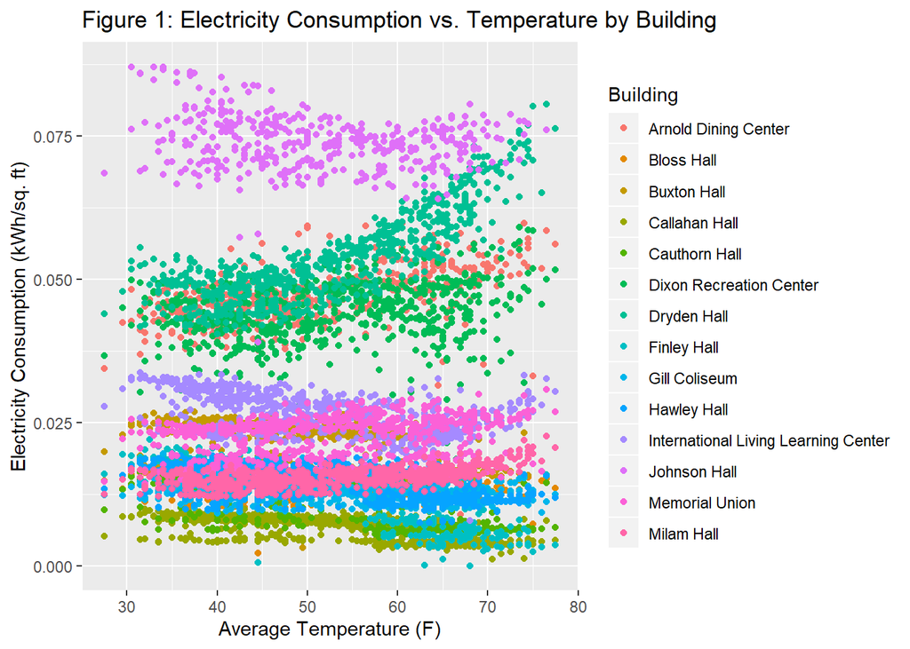

In **Figure 1**, many trends can be observed:

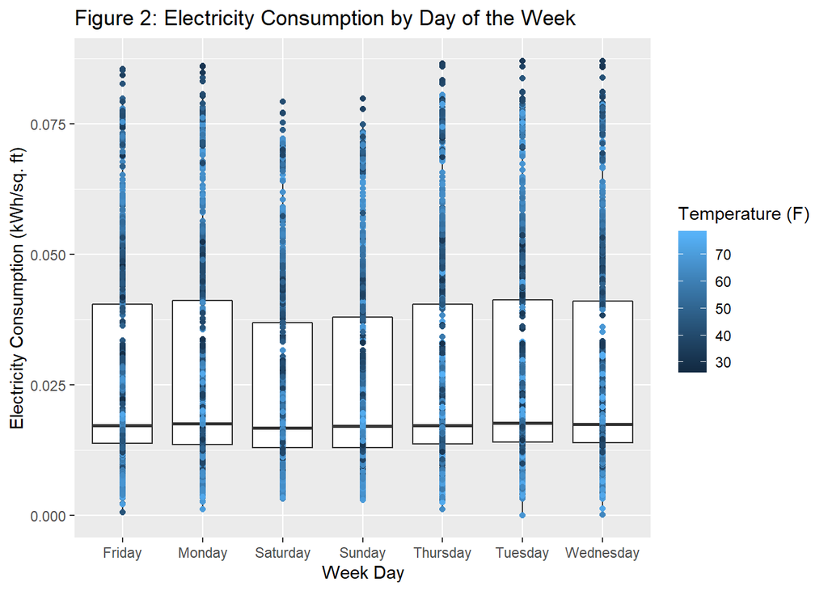

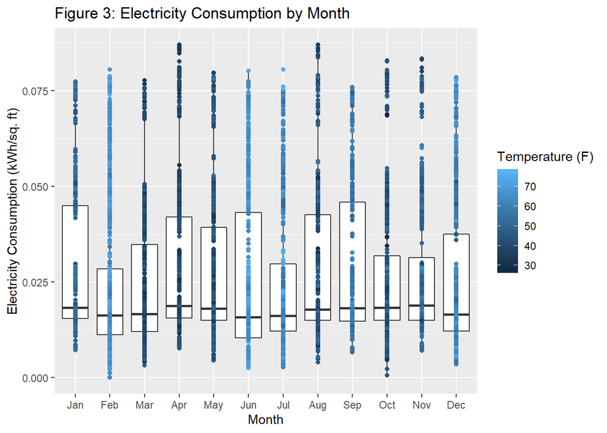

**Figure 2** and **Figure 3** reveal that electricity consumption trends vary widely month-to-month and day-to-day. This reflects building occupancy trends across campus. During summer months and December, typical building utilization is disrupted by students leaving for breaks. This is most likely what is reflected in building electricity consumption.

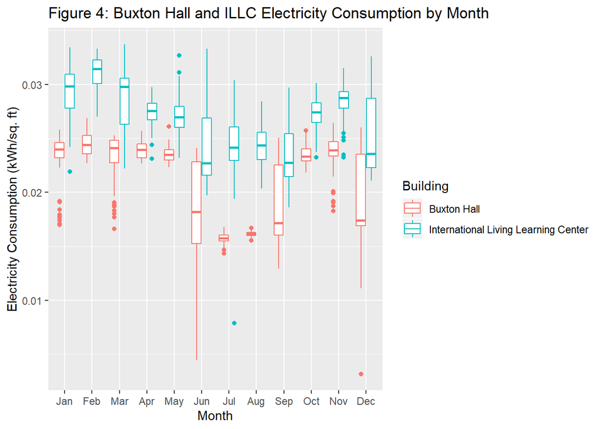

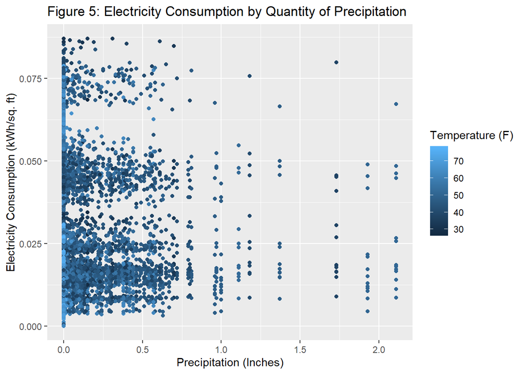

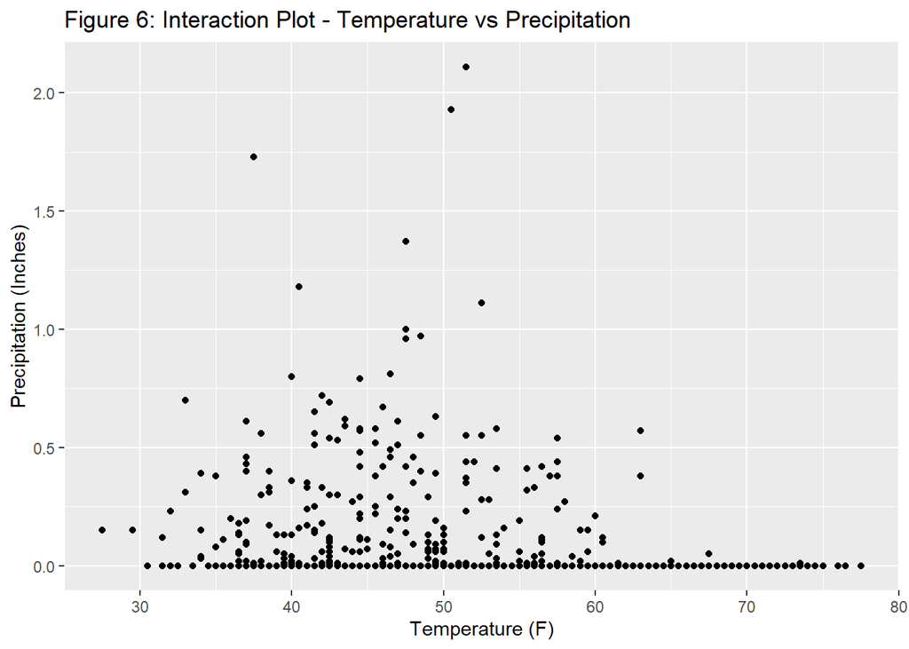

**Figure 5** plots *epsf* and daily *PRCP* in Corvallis and reveals no clear correlation between precipitation and electricity consumption. **Figure 6** illustrates little to no interaction between *Temperature* and *PRCP*. Although I initially thought that the quantity of precipitation would be correlated with higher electricity consumption (since students would likely spend more time indoors), this does not appear to be true.

To summarize everything:

- There is a correlation between temperature and electricity consumption.
- Each building and building type have unique consumption trends.
- Buildings exhibit different energy trends throughout the year. *Month* is likely to be significant in the linear model.
- Electricity consumption trends follow cyclic secondary trends on a weekly basis.

For this report, a least squares linear regression model will be created to find a relationship between outside air temperature and building electricity consumption. In this case, a linear model is a convenient tool because it provides mechanisms which allow an analyst to study the effect of one explanatory variable on the response variable while holding all other factors constant. For example, a slope coefficient would provide a sufficient link between changes in electricity consumption explained by changes in outside air temperature.

## The Model

```
##
## Call:
## lm(formula = epsf ~ TMAX + TMIN + I(TMAX^2) + I(TMIN^2) + Building +
##     Type + PRCP + Month + dayOfWeek, data = energyDailyTotals)
##
## Residuals:
##       Min        1Q    Median        3Q       Max
## -0.036757 -0.002076  0.000115  0.002127  0.024371
##
## Coefficients: (5 not defined because of singularities)
##                                                Estimate Std. Error  t value
## (Intercept)                                   5.699e-02  1.253e-03   45.479
## TMAX                                         -2.618e-04  3.405e-05   -7.688
## TMIN                                         -4.537e-05  5.192e-05   -0.874
## I(TMAX^2)                                     2.339e-06  2.476e-07    9.450
## I(TMIN^2)                                     2.088e-07  6.423e-07    0.325
## BuildingBloss Hall                           -3.209e-02  2.414e-04 -132.952
## BuildingBuxton Hall                          -2.518e-02  2.377e-04 -105.971
## BuildingCallahan Hall                        -4.007e-02  2.316e-04 -173.005
## BuildingCauthorn Hall                        -3.493e-02  2.314e-04 -150.935
## BuildingDixon Recreation Center              -2.488e-03  2.314e-04  -10.750
## BuildingDryden Hall                           7.246e-03  2.314e-04   31.314
## BuildingFinley Hall                          -3.322e-02  2.414e-04 -137.627
## BuildingGill Coliseum                        -3.350e-02  2.318e-04 -144.525
## BuildingHawley Hall                          -3.175e-02  2.314e-04 -137.207
## BuildingInternational Living Learning Center -1.984e-02  2.342e-04  -84.748
## BuildingJohnson Hall                          2.721e-02  2.577e-04  105.581
## BuildingMemorial Union                       -2.410e-02  2.314e-04 -104.130
## BuildingMilam Hall                           -3.113e-02  2.314e-04 -134.533
## TypeDining                                           NA         NA       NA
## TypeEvents                                           NA         NA       NA
## TypeGym                                              NA         NA       NA
## TypeResidence                                        NA         NA       NA
## TypeStadium                                          NA         NA       NA
## PRCP                                          2.419e-04  2.143e-04    1.129
## MonthAugust                                  -3.901e-03  2.990e-04  -13.046
## MonthDecember                                -3.874e-03  2.567e-04  -15.093
## MonthFebruary                                -6.052e-04  2.634e-04   -2.298
## MonthJanuary                                 -1.398e-03  2.481e-04   -5.633
## MonthJuly                                    -3.270e-03  2.939e-04  -11.128
```

[output cut: 45 more lines]

```
## MonthNovember                                2.22e-06 ***
## MonthOctober                                 0.007188 **
## MonthSeptember                                < 2e-16 ***
## dayOfWeekMonday                              0.137080
## dayOfWeekSaturday                             < 2e-16 ***
## dayOfWeekSunday                               < 2e-16 ***
## dayOfWeekThursday                            0.131235
## dayOfWeekTuesday                             0.020835 *
## dayOfWeekWednesday                           0.044284 *
## ---
## Signif. codes:  0 '***' 0.001 '**' 0.01 '*' 0.05 '.' 0.1 ' ' 1
##
## Residual standard error: 0.003869 on 8267 degrees of freedom
## Multiple R-squared:  0.9562, Adjusted R-squared:  0.956
## F-statistic:  5158 on 35 and 8267 DF,  p-value: < 2.2e-16
```

```
## Analysis of Variance Table
##
## Response: epsf
##             Df  Sum Sq  Mean Sq    F value    Pr(>F)
## TMAX         1 0.00165 0.001653   110.3975 < 2.2e-16 ***
## TMIN         1 0.00069 0.000690    46.0741 1.217e-11 ***
## I(TMAX^2)    1 0.00002 0.000021     1.3710  0.241669
## I(TMIN^2)    1 0.00016 0.000157    10.4636  0.001222 **
## Building    13 2.68249 0.206345 13784.1772 < 2.2e-16 ***
## PRCP         1 0.00002 0.000022     1.4479  0.228905
## Month       11 0.01038 0.000943    63.0234 < 2.2e-16 ***
## dayOfWeek    6 0.00700 0.001167    77.9706 < 2.2e-16 ***
## Residuals 8267 0.12375 0.000015
## ---
## Signif. codes:  0 '***' 0.001 '**' 0.01 '*' 0.05 '.' 0.1 ' ' 1
```

The initial ANOVA test found *PRCP*, *Type*, and the squared *TMAX* terms to be insignificant. Interestingly, the other temperatures appear to be significant. This is likely because the minimum and maximum temperatures are highly correlated with one another (Correlation is 0.765271. Removing *PRCP* and *Type* from the model, we obtain:

```
##
## Call:
## lm(formula = epsf ~ TMAX + TMIN + I(TMAX^2) + I(TMIN^2) + Building +
##     Month + dayOfWeek, data = energyDailyTotals)
##
## Residuals:
##       Min        1Q    Median        3Q       Max
## -0.036763 -0.002080  0.000110  0.002126  0.024386
##
## Coefficients:
##                                                Estimate Std. Error  t value
## (Intercept)                                   5.699e-02  1.253e-03   45.473
## TMAX                                         -2.670e-04  3.374e-05   -7.912
## TMIN                                         -3.457e-05  5.104e-05   -0.677
## I(TMAX^2)                                     2.363e-06  2.466e-07    9.583
## I(TMIN^2)                                     1.149e-07  6.369e-07    0.180
## BuildingBloss Hall                           -3.209e-02  2.414e-04 -132.950
## BuildingBuxton Hall                          -2.519e-02  2.377e-04 -105.974
## BuildingCallahan Hall                        -4.007e-02  2.316e-04 -173.007
## BuildingCauthorn Hall                        -3.493e-02  2.314e-04 -150.937
## BuildingDixon Recreation Center              -2.488e-03  2.314e-04  -10.754
## BuildingDryden Hall                           7.245e-03  2.314e-04   31.310
## BuildingFinley Hall                          -3.322e-02  2.414e-04 -137.625
## BuildingGill Coliseum                        -3.350e-02  2.318e-04 -144.527
## BuildingHawley Hall                          -3.175e-02  2.314e-04 -137.209
## BuildingInternational Living Learning Center -1.985e-02  2.342e-04  -84.750
## BuildingJohnson Hall                          2.720e-02  2.577e-04  105.575
## BuildingMemorial Union                       -2.410e-02  2.314e-04 -104.132
## BuildingMilam Hall                           -3.113e-02  2.314e-04 -134.535
## MonthAugust                                  -3.933e-03  2.976e-04  -13.215
## MonthDecember                                -3.886e-03  2.564e-04  -15.156
## MonthFebruary                                -6.066e-04  2.634e-04   -2.303
## MonthJanuary                                 -1.407e-03  2.480e-04   -5.675
## MonthJuly                                    -3.301e-03  2.926e-04  -11.282
## MonthJune                                    -2.523e-03  2.591e-04   -9.740
## MonthMarch                                   -1.015e-03  2.645e-04   -3.836
## MonthMay                                     -5.096e-04  2.721e-04   -1.873
## MonthNovember                                -1.183e-03  2.458e-04   -4.813
## MonthOctober                                 -6.727e-04  2.439e-04   -2.758
## MonthSeptember                               -2.481e-03  2.573e-04   -9.640
```

[output cut: 33 more lines]

```
## MonthNovember                                1.51e-06 ***
## MonthOctober                                 0.005820 **
## MonthSeptember                                < 2e-16 ***
## dayOfWeekMonday                              0.146007
## dayOfWeekSaturday                             < 2e-16 ***
## dayOfWeekSunday                               < 2e-16 ***
## dayOfWeekThursday                            0.145406
## dayOfWeekTuesday                             0.019169 *
## dayOfWeekWednesday                           0.050010 .
## ---
## Signif. codes:  0 '***' 0.001 '**' 0.01 '*' 0.05 '.' 0.1 ' ' 1
##
## Residual standard error: 0.003869 on 8268 degrees of freedom
## Multiple R-squared:  0.9562, Adjusted R-squared:  0.956
## F-statistic:  5309 on 34 and 8268 DF,  p-value: < 2.2e-16
```

```
## Analysis of Variance Table
##
## Model 1: epsf ~ TMAX + TMIN + I(TMAX^2) + I(TMIN^2) + Building + Type +
##     PRCP + Month + dayOfWeek
## Model 2: epsf ~ TMAX + TMIN + I(TMAX^2) + I(TMIN^2) + Building + Month +
##     dayOfWeek
##   Res.Df     RSS Df  Sum of Sq      F Pr(>F)
## 1   8267 0.12376
## 2   8268 0.12377 -1 -1.908e-05 1.2746 0.2589
```

This model does not consider the correlation between temperatures, however. To construct the final model, we remove the squared *TMAX* term and create an interaction term between *Building* and the squared *TMIN* term. Lastly, we introduce a interaction terms between *Building* and *Month* & *dayOfWeek*.

```
##
## Call:
## lm(formula = epsf ~ TMAX + TMIN + I(TMIN^2) * Building + Building *
##     Month + Building * dayOfWeek + Building + Month + dayOfWeek,
##     data = energyDailyTotals)
##
## Residuals:
##       Min        1Q    Median        3Q       Max
## -0.034384 -0.001087  0.000036  0.001105  0.016762
##
## Coefficients:
##                                                                   Estimate
## (Intercept)                                                      5.008e-02
## TMAX                                                             4.756e-05
## TMIN                                                            -2.029e-04
## I(TMIN^2)                                                        3.845e-06
## BuildingBloss Hall                                              -3.235e-02
## BuildingBuxton Hall                                             -2.287e-02
## BuildingCallahan Hall                                           -3.999e-02
## BuildingCauthorn Hall                                           -3.221e-02
## BuildingDixon Recreation Center                                  4.771e-04
## BuildingDryden Hall                                             -4.375e-04
## BuildingFinley Hall                                             -3.016e-02
## BuildingGill Coliseum                                           -3.415e-02
## BuildingHawley Hall                                             -3.078e-02
## BuildingInternational Living Learning Center                    -1.935e-02
## BuildingJohnson Hall                                             2.642e-02
## BuildingMemorial Union                                          -2.388e-02
## BuildingMilam Hall                                              -3.281e-02
## MonthAugust                                                     -1.041e-02
## MonthDecember                                                   -6.777e-03
## MonthFebruary                                                   -3.959e-03
## MonthJanuary                                                    -4.177e-03
## MonthJuly                                                       -2.243e-03
## MonthJune                                                       -7.811e-04
## MonthMarch                                                      -4.673e-03
## MonthMay                                                        -1.124e-03
## MonthNovember                                                   -5.882e-03
## MonthOctober                                                    -4.987e-03
## MonthSeptember                                                  -2.534e-03
```

[output cut: 1038 more lines]

```
## BuildingDixon Recreation Center:dayOfWeekWednesday              0.722729
## BuildingDryden Hall:dayOfWeekWednesday                          0.959522
## BuildingFinley Hall:dayOfWeekWednesday                          0.595460
## BuildingGill Coliseum:dayOfWeekWednesday                        0.018637 *
## BuildingHawley Hall:dayOfWeekWednesday                          0.349854
## BuildingInternational Living Learning Center:dayOfWeekWednesday 0.882968
## BuildingJohnson Hall:dayOfWeekWednesday                         0.106462
## BuildingMemorial Union:dayOfWeekWednesday                       0.878846
## BuildingMilam Hall:dayOfWeekWednesday                           0.767360
## ---
## Signif. codes:  0 '***' 0.001 '**' 0.01 '*' 0.05 '.' 0.1 ' ' 1
##
## Residual standard error: 0.00263 on 8035 degrees of freedom
## Multiple R-squared:  0.9803, Adjusted R-squared:  0.9797
## F-statistic:  1501 on 267 and 8035 DF,  p-value: < 2.2e-16
```

```
## Analysis of Variance Table
##
## Response: epsf
##                      Df  Sum Sq  Mean Sq   F value    Pr(>F)
## TMAX                  1 0.00165 0.001653   238.991 < 2.2e-16 ***
## TMIN                  1 0.00069 0.000690    99.742 < 2.2e-16 ***
## I(TMIN^2)             1 0.00018 0.000177    25.560 4.382e-07 ***
## Building             13 2.68242 0.206340 29839.526 < 2.2e-16 ***
## Month                11 0.00916 0.000833   120.432 < 2.2e-16 ***
## dayOfWeek             6 0.00692 0.001153   166.778 < 2.2e-16 ***
## I(TMIN^2):Building   13 0.03955 0.003042   439.920 < 2.2e-16 ***
## Building:Month      143 0.02059 0.000144    20.826 < 2.2e-16 ***
## Building:dayOfWeek   78 0.00945 0.000121    17.514 < 2.2e-16 ***
## Residuals          8035 0.05556 0.000007
## ---
## Signif. codes:  0 '***' 0.001 '**' 0.01 '*' 0.05 '.' 0.1 ' ' 1
```

The interaction terms were included in this model because:

- Some buildings exhibited curvature in **Figure 1**, while others did not.
- Electricity consumption in residence halls decreases significantly over the summer months, while academic buildings exhibit different effects.
- Some buildings, such as residence halls, have similar occupancy on weekends vs weekdays while academic buildings do not.

Overall, this change improved the $R^2$ and $R^2_{adj}$ values significantly.

# Results

Overall, the final model captures electricity consumption trends reasonably well. **Figure 7** depicts relatively consistent and small residuals, and **Figure 8** shows predicted kWh daily consumption for the Memorial Union. Considering that many factors (such as building occupancy, age, and HVAC system types) were not specifically addressed in the model, I believe the model performs well.

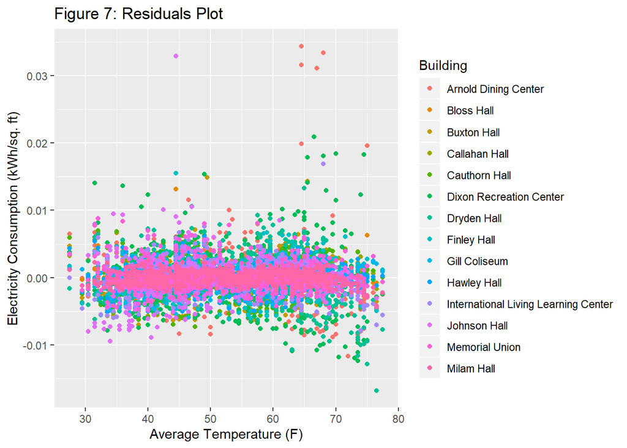

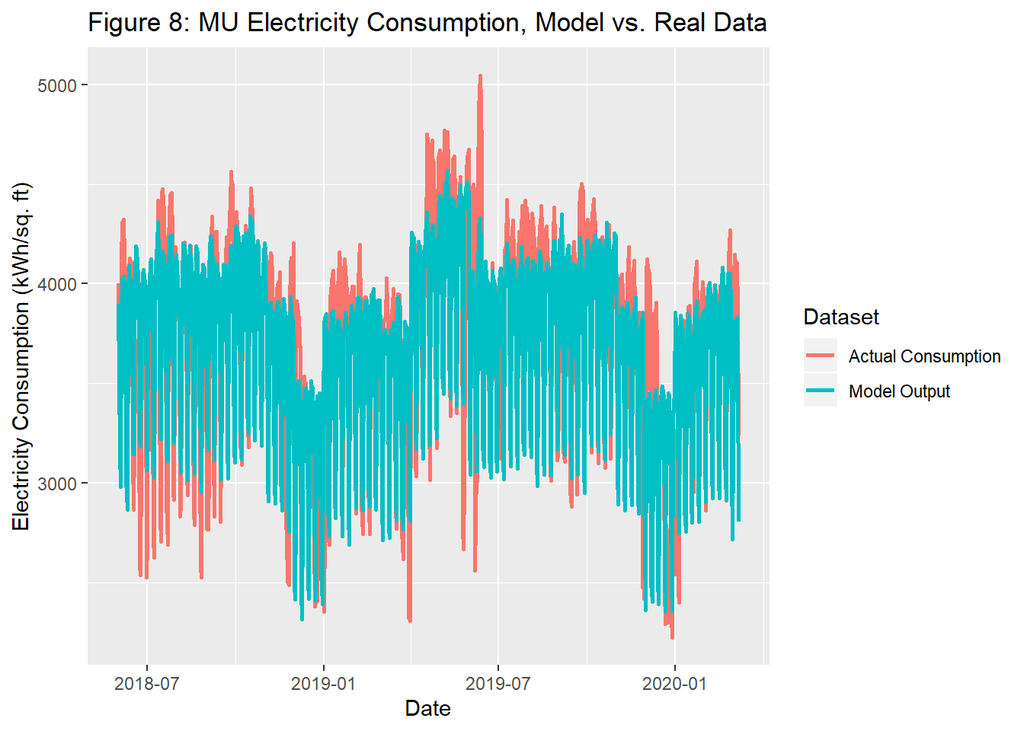

# Discussion

It is important to note that inferences derived from the model will be limited by the following:

### Location Constraints

The data collected for this project originates at only the Corvallis Campus. The results of this report may not accurately project electricity consumption trends across all OSU-owned properties. Additionally, a small subset of OSU buildings in Corvallis were used to construct this model.

### Limited Time-Series Data

All of the data used in this report spans less than two years of consumption data. To really understand long term electricity consumption trends, a broader time span is required for accurate prediction.

### Correlation & Colinearity

For simplicity, the model does not account for correlation between neighboring time-series observations. Additionally, the model does not consider the correlation that may exist between *Temperature* & *Month* or *Temperature* and *Year*.

For the purposes of this Final Project, the findings in this report are sufficient for finding a link between climate changes and electricity consumption trends. I do not believe the findings of this report are sufficient grounds for institutional decision-making; however, with more data, time, and resources, I believe a more accurate model could be produced that accurately projects energy consumption over a longer time interval. As OSU continues to expand smart metering programs and develops novel ways to collect more building data (such as building occupancy, or device-specific electric metering), an accurate model could be created.

# Conclusions

Maximum and minimum daily temperatures have a statistically significant effect on building electricity consumption. For each 1 degree increase in maximum temperature, facility operators can expect a 0.00004756 increase in *kWh/sq. ft.* consumption campus wide. The effect of minimum temperature changes is hard to quantify because it is almost negligible campus wide but varies immensely by building. **Figure 9** depicts the effect of a 2 degree celsius increase in daily temperature.

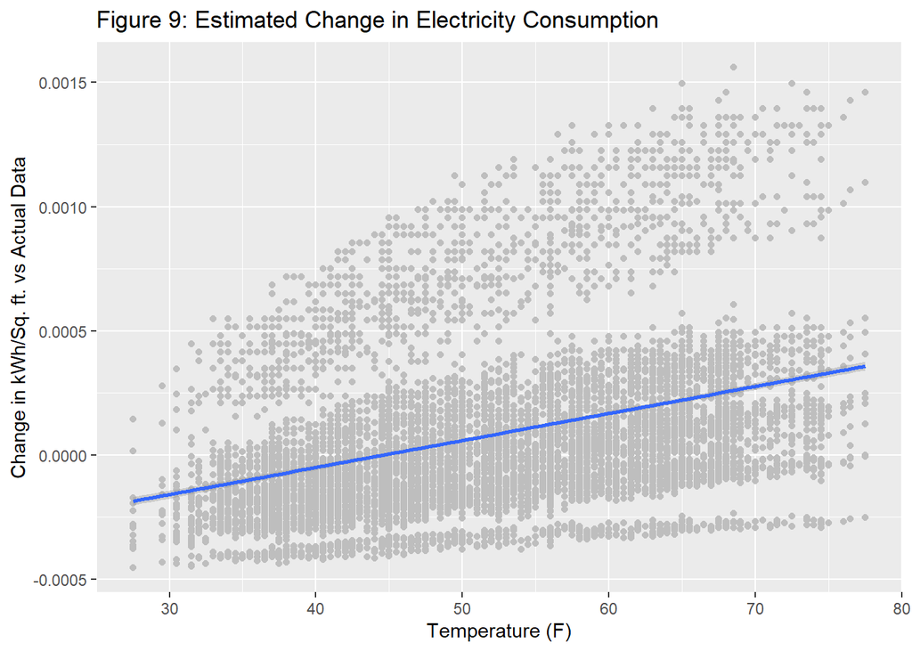

# Informal Sources Cited

OSU Carbon Commitment and Emissions Statistics - https://fa.oregonstate.edu/sustainability/planning-policy-assessment/institutional-carbon-neutrality

Carbon Emissions Breakdown - https://fa.oregonstate.edu/sustainability/planning-policy-assessment/institutional-carbon-neutrality/emissions-measurement-and

Electricity Data - https://dashboard.sustainability.oregonstate.edu/

Weather Data - https://www.ncdc.noaa.gov/cdo-web/

Building Square Footage and Other Data - Available upon request from the OSU Sustainability Office. Contact Lety: leticia.cavazos@oregonstate.edu